# PD signatures in BugSigDB

```r
# data manipulation packages
library(tidyverse)
library(magrittr)

# table visualization packages
library(reactable)
library(kableExtra)

# data visualization packages
library(pheatmap)
library(ggpubr)
library(plotly)

# bugSigDB packages for literature review
library(bugsigdbr)
library(bugSigSimple)
library(BugSigDBStats)


# to record continent of origin
library(countrycode)
```

# 1 PD studies in `BugSigDB`

We first summarize bacterial signatures found in previous literature. To ensure reproducibility, we will use bacterial signatures (meaning differentially abundant taxa) for Parkinson’s Disease found in the BugSigDB resource.

```r
# define query
condition_of_interest <- "Parkinson disease"
efo_id <- "MONDO:0005180"
host <- "Homo sapiens"

cbind(c("Condition", "EFO ID", "Host species"), c(condition_of_interest, efo_id, host)) %>%
  set_colnames(c("Parameter", "Value")) %>%
  kbl() %>%
  kable_styling()
```

| Parameter | Value |
| --- | --- |
| Condition | Parkinson disease |
| EFO ID | MONDO:0005180 |
| Host species | Homo sapiens |

Table below: Overview of ALL studies related to Parkinson in BugSigDB. The table has been sorted to show shotgun studies on top. **Important**: some studies appear more than once because curators have reported more than one experiment, like comparing multiple groups. This implies potentially different cases and controls.

```r
bsdb <- importBugSigDB(cache=FALSE)

bsdb_PD_signatures_allMethods <- filter(bsdb,
       # get studies/signatures on Parkinson alone
       grepl(efo_id, `EFO ID`),
       # restrict search to Homo sapiens
       `Host species` == host
       )

# fix typo of feces,blood

bsdb_PD_signatures_allMethods <- mutate(bsdb_PD_signatures_allMethods,
                                        `Body site` = ifelse(`Body site` == "Feces,Blood", "Blood,Feces", `Body site`))

# create a continent variable
bsdb_PD_signatures_allMethods$Continent <- strsplit(bsdb_PD_signatures_allMethods$`Location of subjects`, ",") %>%
  lapply(
    function(x){
      tmp <- countrycode(x, origin = "country.name", "continent")
      tmp[(tmp == "Americas") & (x %in% c("United States of America", "Canada"))] <- "North America"
      tmp[(tmp == "Americas") & !(x %in% c("United States of America", "Canada"))] <- "South America"
      return(tmp)
      }) %>%
  sapply(paste, collapse = ",")

source(file = "~/Desktop/bugSigSimple_upgrade.R")

# custom, more expanded createStudyTable function
studies_table_clean <- createStudyTable2(bsdb_PD_signatures_allMethods, rows_are = "experiments", includeAlso = c("Sequencing type", "Sequencing platform"))

studies_table_clean %>%
  reactable(filterable = TRUE, searchable = TRUE)
```

| StudyCount | Study code | Condition | Body site | Experiment | Cases | Controls | Study design | Sequencing type | Sequencing platform | PMID | DOI |
| --- | --- | --- | --- | --- | --- | --- | --- | --- | --- | --- | --- |
| 1 | AhoVTE_2019 | Parkinson's disease | Feces | Experiment 1 | 64 | 64 | case-control | 16S | Illumina | 31221587 | https://doi.org/10.1016/j.ebiom.2019.05.064 |
| 1 | AhoVTE_2019 | Parkinson's disease | Feces | Experiment 2 | 15 | 41 | case-control | 16S | Illumina | 31221587 | https://doi.org/10.1016/j.ebiom.2019.05.064 |
| 1 | AhoVTE_2019 | Parkinson's disease | Feces | Experiment 3 | 64 | 64 | case-control | 16S | Illumina | 31221587 | https://doi.org/10.1016/j.ebiom.2019.05.064 |
| 1 | AhoVTE_2019 | Parkinson's disease | Feces | Experiment 4 | 28 | 21 | case-control | 16S | Illumina | 31221587 | https://doi.org/10.1016/j.ebiom.2019.05.064 |
| 1 | AhoVTE_2019 | Parkinson's disease | Feces | Experiment 5 | 35 | 20 | case-control | 16S | Illumina | 31221587 | https://doi.org/10.1016/j.ebiom.2019.05.064 |
| 1 | AhoVTE_2019 | Parkinson's disease | Feces | Experiment 6 | 15 | 41 | case-control | 16S | Illumina | 31221587 | https://doi.org/10.1016/j.ebiom.2019.05.064 |
| 2 | AhoVTE_2021 | Parkinson's disease | Feces | Experiment 1 | 55 | 56 | case-control | 16S | Illumina | 33557896 | https://doi.org/10.1186/s13024-021-00427-6 |
| 3 | AhoVTE_2024 | Parkinson's disease | Feces | Experiment 1 | 60 | 90 | case-control | 16S | Illumina | 38582855 | https://doi.org/10.1038/s41531-024-00687-1 |
| 3 | AhoVTE_2024 | Parkinson's disease | Feces | Experiment 3 | 58 | 90 | case-control | 16S | Illumina | 38582855 | https://doi.org/10.1038/s41531-024-00687-1 |
| 3 | AhoVTE_2024 | Parkinson's disease | Feces | Experiment 4 | 60 | 90 | case-control | 16S | Illumina | 38582855 | https://doi.org/10.1038/s41531-024-00687-1 |

[output cut: 126 more lines]

Below the summary function as currently implemented in bugSigSimple

```r
createStudyTable(bsdb_PD_signatures_allMethods) %>%
  reactable(filterable = TRUE)
```

| Study | Condition | Cases | Controls | Study Design |
| --- | --- | --- | --- | --- |
| Aho 2019 | Parkinson's disease | 64 | 64 | case-control |
| Aho 2021 | Parkinson's disease | 55 | 56 | case-control |
| Aho 2024 | Parkinson's disease | 60 | 90 | case-control |
| Baldini 2020 | Parkinson's disease | 147 | 162 | case-control |
| Barichella 2019 | Parkinson's disease | 193 | 113 | case-control |
| Bedarf 2017 | Parkinson's disease | 31 | 28 | case-control |
| Boertien 2022 | Parkinson's disease | 136 | 87 | case-control |
| Boktor 2023 | Parkinson's disease | 88 | 83 | meta-analysis |
| Burns 2017 | Parkinson's disease | 197 | 130 | case-control |
| Buschart 2018 | Parkinson's disease | 76 | 78 | case-control |

[output cut: 42 more lines]

# 2 Some statistics of studies included (For CRN meeting)

```
## $`1`
```

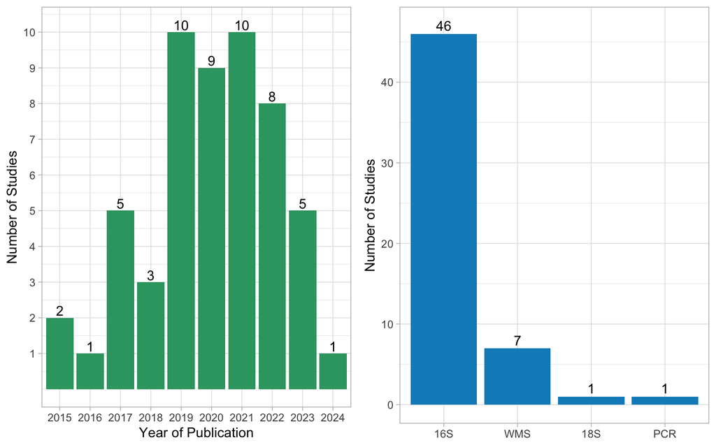

```
##
## $`2`
```

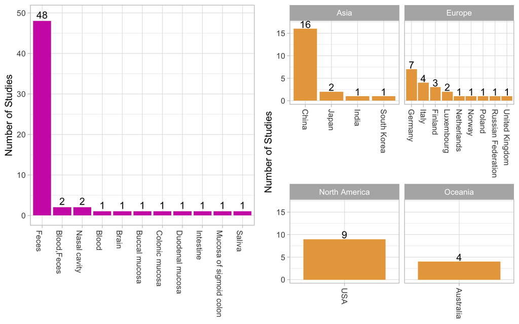

```
##
## attr(,"class")
## [1] "list"      "ggarrange"
```

```r
# NUmber of studies per year

studies_per_year <- bsdb_PD_signatures_allMethods %>% select(PMID, Year) %>% distinct() %>% .$Year %>% table() %>% as.data.frame() %>% arrange(desc(Freq)) %>% set_colnames(c("Year of Publication", "Number of Studies"))

years_barplot <- ggplot(studies_per_year, aes(x = `Year of Publication`, y = `Number of Studies`)) +
  geom_col(fill = "#34a270") +
  geom_text(data = studies_per_year, mapping = aes(x = `Year of Publication`, y = `Number of Studies` + 0.2, label = `Number of Studies`)) +
  theme_light() +
  scale_y_continuous(breaks = 1:10)

ggsave(filename = "~/Desktop/CRN_MEETING/studies_per_year.png", plot =  years_barplot, height = 4, width = 5, dpi = 300, bg = "transparent")

# Body sites

bodySites <- bsdb_PD_signatures_allMethods %>% select(PMID, `Body site`) %>% distinct() %>% mutate(`Body site` = ifelse(`Body site` == "Feces,Blood", "Blood,Feces", `Body site`)) %>% .$`Body site` %>% table() %>% as.data.frame() %>% arrange(desc(Freq)) %>% set_colnames(c("Body Site", "Number of Studies"))

bodySite_barplot <- ggplot(bodySites, aes(x = reorder(`Body Site`, - `Number of Studies`), y = `Number of Studies`)) +
  geom_col(fill = "#cf2fb3") +
  geom_text(data = bodySites, mapping = aes(x = reorder(`Body Site`, - `Number of Studies`), y = `Number of Studies` + 1.5, label = `Number of Studies`)) +
  theme_light() +
  theme(axis.text.x = element_text(angle = -90, hjust = 0), axis.title.x = element_blank())

ggsave(filename = "~/Desktop/CRN_MEETING/BodySites.png", plot = bodySite_barplot, height = 4, width = 5, dpi = 300, bg = "transparent")

# Census methods

censusMethods <- bsdb_PD_signatures_allMethods %>% select(PMID, `Sequencing type`) %>% distinct() %>% .$`Sequencing type` %>% table() %>% as.data.frame() %>% arrange(desc(Freq)) %>% set_colnames(c("Census Method", "Number of Studies"))

censusMethods_barplot <- ggplot(censusMethods, aes(x = reorder(`Census Method`, - `Number of Studies`), y = `Number of Studies`)) +
  geom_col(fill = "#0c8dc3") +
  geom_text(data = censusMethods, mapping = aes(x = reorder(`Census Method`, - `Number of Studies`), y = `Number of Studies` + 1, label = `Number of Studies`)) +
  theme_light() +
  theme(axis.title.x = element_blank())

ggsave(filename = "~/Desktop/CRN_MEETING/CensusMethods.png", plot = censusMethods_barplot, height = 4, width = 5, dpi = 300, bg = "transparent")

# Census methods

location.df <- bsdb_PD_signatures_allMethods %>% select(PMID, `Location of subjects`) %>% distinct() %>% .$`Location of subjects` %>% table() %>% as.data.frame() %>% arrange(desc(Freq)) %>% set_colnames(c("Location of subjects", "Number of Studies")) %>%
  left_join(bsdb_PD_signatures_allMethods %>% select(`Location of subjects`, Continent), by = "Location of subjects") %>%
  # for now, remove multi-country studies
  filter(!grepl(",", `Location of subjects`)) %>%
  distinct() %>%
  mutate(`Location of subjects` = case_when(
    `Location of subjects` == "United States of America" ~ "USA",
    TRUE ~ `Location of subjects`
    ))

location_barplot <- ggplot(location.df, aes(x = reorder(`Location of subjects`, - `Number of Studies`), y = `Number of Studies`)) +
  geom_col(fill = "#e9a64c") +
  geom_text(data = location.df, mapping = aes(x = reorder(`Location of subjects`, - `Number of Studies`), y = `Number of Studies` + 1, label = `Number of Studies` )) +
  theme_light() +
  facet_wrap(~Continent,scales = "free_x") +
  theme(axis.text.x = element_text(angle = -90, hjust = 0, vjust = 0.5), axis.title.x = element_blank())


ggsave(filename = "~/Desktop/CRN_MEETING/GeographicDistribution.png", plot = location_barplot, height = 5, width = 5, dpi = 300, bg = "transparent")

ggarrange(
  years_barplot, censusMethods_barplot,
  bodySite_barplot, location_barplot,
  ncol = 2
  )
```

# 3 Significant signatures across studies (Binomial test p-value < 0.05)

The function `bugSigSimple::createTaxonTable` generates a list of microbes that are most frequently reported in the papers tested. Next, for each microbe, it counts how many times it was reported to be enriched or depleted across studies.

To test if a bug is significantly more often reported as increased or decreased, a binomial test is run, assuming a 0.5 probability for the null hypothesis. The more disproportionate two groups, the more significant the test is.

## 3.1 All studies

```r
tmp <- createTaxonTable(bsdb_PD_signatures_allMethods, Inf) %>%
  filter(`Binomial Test pval` < 0.05) %>%
  kbl(caption = "Number of significant signatures as found in BugSigDB. Significance is defined as binomial test p-value less than 0.05. Signautres were extracted using bugSigSimple::createTaxonTable") %>%
  kable_styling()
```

## 3.2 Studies split by `Sequencing type`

```r
signautres_per_body_site <- bsdb_PD_signatures_allMethods %>%
  mutate(`Sequencing type` = ifelse(`Sequencing type` == "Feces,Blood", "Blood,Feces", `Sequencing type`)) %>%
split.data.frame(f = .$`Sequencing type`) %>%
  # in the list of each body site, report all possible signatures
  lapply(function(x) tryCatch(createTaxonTable(x, n = Inf), error = function(e) return(NULL))) %>%
  .[!sapply(., is.null)] %>%
  lapply(dplyr::filter, `Binomial Test pval` < 0.05)
cbind(names(signautres_per_body_site), sapply(signautres_per_body_site, nrow)) %>%
  set_colnames(c("Sequencing type", "Significantly enriched Signatures")) %>%
  set_rownames(NULL) %>%
  kbl(caption = "Number of significant signatures as found in BugSigDB subdividing studies by sequencing type, or more generally microbial census method (PCR is not sequencing). Significance is defined as binomial test p-value less than 0.05, testing for each  disproportions. Signautres were extracted using bugSigSimple::createTaxonTable") %>%
  kable_styling()
```

Table 3.1: Number of significant signatures as found in BugSigDB subdividing studies by sequencing type, or more generally microbial census method (PCR is not sequencing). Significance is defined as binomial test p-value less than 0.05, testing for each disproportions. Signautres were extracted using bugSigSimple::createTaxonTable

| Sequencing type | Significantly enriched Signatures |
| --- | --- |
| 16S | 23 |
| 18S | 0 |
| PCR | 0 |
| WMS | 0 |

## 3.3 Studies spliy by `Body site`

```r
signautres_per_body_site <- bsdb_PD_signatures_allMethods %>%
  mutate(`Body site` = ifelse(`Body site` == "Feces,Blood", "Blood,Feces", `Body site`)) %>%
split.data.frame(f = .$`Body site`) %>%
  # in the list of each body site, report all possible signatures
  lapply(function(x) tryCatch(createTaxonTable(x, n = Inf), error = function(e) return(NULL))) %>%
  .[!sapply(., is.null)] %>%
  lapply(dplyr::filter, `Binomial Test pval` < 0.05)
cbind(names(signautres_per_body_site), sapply(signautres_per_body_site, nrow)) %>%
  set_colnames(c("Body Site", "Significantly enriched Signatures")) %>%
  set_rownames(NULL) %>%
  kbl(caption = "Number of significant signatures as found in BugSigDB. Significance is defined as binomial test p-value less than 0.05. Signautres were extracted using bugSigSimple::createTaxonTable") %>%
  kable_styling()
```

Table 3.2: Number of significant signatures as found in BugSigDB. Significance is defined as binomial test p-value less than 0.05. Signautres were extracted using bugSigSimple::createTaxonTable

| Body Site | Significantly enriched Signatures |
| --- | --- |
| Blood,Feces | 0 |
| Brain | 0 |
| Buccal mucosa | 0 |
| Colonic mucosa | 0 |
| Duodenal mucosa | 0 |
| Feces | 25 |
| Mucosa of sigmoid colon | 0 |
| Nasal cavity | 0 |
| Saliva | 0 |

## 3.4 Summary of signatures’s evidence

- Without pre-filtering, 26 bugs are differentially abundant in the same direction across studies
- If split by sequencing/census method, only 16S returns significant signatures
- If split by body site, only `Feces` show associations.

We will continue studying all stool signatures only, given that other body sites do not show consensus.

# 4 Signatures for each body site in only `Body site = Feces` studies

```r
bsdb_PD_signatures_allMethods_onlyFeces <- filter(bsdb_PD_signatures_allMethods, `Body site` == "Feces")
bsdb_PD_signatures_allMethods_onlyFeces.list <- split.data.frame(bsdb_PD_signatures_allMethods_onlyFeces, bsdb_PD_signatures_allMethods_onlyFeces$`Sequencing type`)

some_stats.mxt <- cbind(
  sapply(bsdb_PD_signatures_allMethods_onlyFeces.list, nrow),
  t(sapply(bsdb_PD_signatures_allMethods_onlyFeces.list, function(x) table(x$`Abundance in Group 1`, useNA = "always")))
  ) %>%
  set_colnames(c("Total Signatures", "Decreased in PD", "Increased in PD", "NA"))

caption <- paste0("Summary table of BugSigDB signatures reported for Parkinson's disease (EFO/MONDO code ", efo_id, "). Signatures were split by sequencing method in rows. Date of analysis: ", Sys.Date(), ", bugsigdbr package version: ", packageVersion("bugsigdbr"))

kbl(some_stats.mxt, caption = caption) %>%
  kable_styling()
```

Table 4.1: Summary table of BugSigDB signatures reported for Parkinson’s disease (EFO/MONDO code MONDO:0005180). Signatures were split by sequencing method in rows. Date of analysis: 2025-03-17, bugsigdbr package version: 1.13.0

|  | Total Signatures | Decreased in PD | Increased in PD | NA |
| --- | --- | --- | --- | --- |
| 16S | 177 | 81 | 92 | 4 |
| 18S | 2 | 1 | 1 | 0 |
| PCR | 3 | 2 | 1 | 0 |
| WMS | 18 | 9 | 9 | 0 |

```r
createTaxonTable(bsdb_PD_signatures_allMethods_onlyFeces, n = 20) %>%
  kbl(caption = "List of top 20 signatures found in gut microbiome (Feces) across Parkinson studies regardless of the sequencing technique. The table was generated with bugSigSimple::createTaxonTable") %>%
  kable_styling()
```

Table 4.2: List of top 20 signatures found in gut microbiome (Feces) across Parkinson studies regardless of the sequencing technique. The table was generated with bugSigSimple::createTaxonTable

| Taxon Name | Taxonomic Level | total_signatures | increased_signatures | decreased_signatures | Binomial Test pval | kingdom | phylum | class | order | family | genus | species | n_signatures | metaphlan_name |
| --- | --- | --- | --- | --- | --- | --- | --- | --- | --- | --- | --- | --- | --- | --- |
| Lachnospiraceae | family | 47 | 9 | 38 | 2.5e-05 | Bacteria | Bacillota | Clostridia | Lachnospirales | Lachnospiraceae | NA | NA | 97 | k__Bacteria\|p__Bacillota\|c__Clostridia\|o__Lachnospirales\|f__Lachnospiraceae |
| Roseburia | genus | 31 | 2 | 29 | 5.0e-07 | Bacteria | Bacillota | Clostridia | Lachnospirales | Lachnospiraceae | Roseburia | NA | 36 | k__Bacteria\|p__Bacillota\|c__Clostridia\|o__Lachnospirales\|f__Lachnospiraceae\|g__Roseburia |
| Faecalibacterium | genus | 30 | 5 | 25 | 3.2e-04 | Bacteria | Bacillota | Clostridia | Eubacteriales | Oscillospiraceae | Faecalibacterium | NA | 38 | k__Bacteria\|p__Bacillota\|c__Clostridia\|o__Eubacteriales\|f__Oscillospiraceae\|g__Faecalibacterium |
| Akkermansia | genus | 25 | 25 | 0 | 1.0e-07 | Bacteria | Verrucomicrobiota | Verrucomicrobiia | Verrucomicrobiales | Akkermansiaceae | Akkermansia | NA | 27 | k__Bacteria\|p__Verrucomicrobiota\|c__Verrucomicrobiia\|o__Verrucomicrobiales\|f__Akkermansiaceae\|g__Akkermansia |
| Oscillospiraceae | family | 23 | 13 | 10 | 6.8e-01 | Bacteria | Bacillota | Clostridia | Eubacteriales | Oscillospiraceae | NA | NA | 88 | k__Bacteria\|p__Bacillota\|c__Clostridia\|o__Eubacteriales\|f__Oscillospiraceae |
| Bifidobacterium | genus | 20 | 19 | 1 | 4.0e-05 | Bacteria | Actinomycetota | Actinomycetes | Bifidobacteriales | Bifidobacteriaceae | Bifidobacterium | NA | 26 | k__Bacteria\|p__Actinomycetota\|c__Actinomycetes\|o__Bifidobacteriales\|f__Bifidobacteriaceae\|g__Bifidobacterium |
| Bacillota | phylum | 20 | 6 | 14 | 1.2e-01 | Bacteria | Bacillota | NA | NA | NA | NA | NA | 172 | k__Bacteria\|p__Bacillota |
| Lactobacillus | genus | 20 | 14 | 6 | 1.2e-01 | Bacteria | Bacillota | Bacilli | Lactobacillales | Lactobacillaceae | Lactobacillus | NA | 22 | k__Bacteria\|p__Bacillota\|c__Bacilli\|o__Lactobacillales\|f__Lactobacillaceae\|g__Lactobacillus |
| Prevotella | genus | 20 | 6 | 14 | 1.2e-01 | Bacteria | Bacteroidota | Bacteroidia | Bacteroidales | Prevotellaceae | Prevotella | NA | 21 | k__Bacteria\|p__Bacteroidota\|c__Bacteroidia\|o__Bacteroidales\|f__Prevotellaceae\|g__Prevotella |
| Verrucomicrobiaceae | family | 19 | 19 | 0 | 3.8e-06 | Bacteria | Verrucomicrobiota | Verrucomicrobiia | Verrucomicrobiales | Verrucomicrobiaceae | NA | NA | 19 | k__Bacteria\|p__Verrucomicrobiota\|c__Verrucomicrobiia\|o__Verrucomicrobiales\|f__Verrucomicrobiaceae |
| Verrucomicrobiota | phylum | 18 | 18 | 0 | 7.6e-06 | Bacteria | Verrucomicrobiota | NA | NA | NA | NA | NA | 37 | k__Bacteria\|p__Verrucomicrobiota |
| Lactobacillaceae | family | 17 | 11 | 6 | 3.3e-01 | Bacteria | Bacillota | Bacilli | Lactobacillales | Lactobacillaceae | NA | NA | 29 | k__Bacteria\|p__Bacillota\|c__Bacilli\|o__Lactobacillales\|f__Lactobacillaceae |
| Enterobacteriaceae | family | 17 | 14 | 3 | 1.3e-02 | Bacteria | Pseudomonadota | Gammaproteobacteria | Enterobacterales | Enterobacteriaceae | NA | NA | 29 | k__Bacteria\|p__Pseudomonadota\|c__Gammaproteobacteria\|o__Enterobacterales\|f__Enterobacteriaceae |
| Bifidobacteriaceae | family | 16 | 16 | 0 | 3.1e-05 | Bacteria | Actinomycetota | Actinomycetes | Bifidobacteriales | Bifidobacteriaceae | NA | NA | 30 | k__Bacteria\|p__Actinomycetota\|c__Actinomycetes\|o__Bifidobacteriales\|f__Bifidobacteriaceae |
| Blautia | genus | 16 | 2 | 14 | 4.2e-03 | Bacteria | Bacillota | Clostridia | Lachnospirales | Lachnospiraceae | Blautia | NA | 21 | k__Bacteria\|p__Bacillota\|c__Clostridia\|o__Lachnospirales\|f__Lachnospiraceae\|g__Blautia |
| Streptococcus | genus | 14 | 8 | 6 | 7.9e-01 | Bacteria | Bacillota | Bacilli | Lactobacillales | Streptococcaceae | Streptococcus | NA | 17 | k__Bacteria\|p__Bacillota\|c__Bacilli\|o__Lactobacillales\|f__Streptococcaceae\|g__Streptococcus |
| Pseudomonadota | phylum | 14 | 13 | 1 | 1.8e-03 | Bacteria | Pseudomonadota | NA | NA | NA | NA | NA | 59 | k__Bacteria\|p__Pseudomonadota |
| Streptococcaceae | family | 13 | 7 | 6 | 1.0e+00 | Bacteria | Bacillota | Bacilli | Lactobacillales | Streptococcaceae | NA | NA | 26 | k__Bacteria\|p__Bacillota\|c__Bacilli\|o__Lactobacillales\|f__Streptococcaceae |
| Clostridia | class | 13 | 6 | 7 | 1.0e+00 | Bacteria | Bacillota | Clostridia | NA | NA | NA | NA | 146 | k__Bacteria\|p__Bacillota\|c__Clostridia |
| Christensenellaceae | family | 13 | 13 | 0 | 2.4e-04 | Bacteria | Bacillota | Clostridia | Christensenellales | Christensenellaceae | NA | NA | 16 | k__Bacteria\|p__Bacillota\|c__Clostridia\|o__Christensenellales\|f__Christensenellaceae |

## 4.1 Shotgun studies only

We are mostly interested in shotgun sequencing studies, as they are more comparable across studies.

```r
studies_table_clean %>%
  filter(`Sequencing type` == "WMS") %>%
  reactable(filterable = TRUE)
```

| StudyCount | Study code | Condition | Body site | Experiment | Cases | Controls | Study design | Sequencing type | Sequencing platform | PMID | DOI |
| --- | --- | --- | --- | --- | --- | --- | --- | --- | --- | --- | --- |
| 8 | BoktorJC_2023 | Parkinson's disease | Feces | Experiment 1 | 88 | 56 | meta-analysis | WMS | Illumina | 36691982 | https://doi.org/10.1002/mds.29300 |
| 8 | BoktorJC_2023 | Parkinson's disease | Feces | Experiment 2 | 88 | 83 | meta-analysis | WMS | Illumina | 36691982 | https://doi.org/10.1002/mds.29300 |
| 17 | JoS_2022 | Parkinson's disease | Feces | Experiment 5 | 88 | 84 | case-control | WMS | Illumina | 35798742 | https://doi.org/10.1038/s41531-022-00351-6 |
| 28 | MaoL_2021 | Parkinson's disease | Feces | Experiment 1 | 39 | 39 | cross-sectional observational, not case-control | WMS | BGISEQ-500 Sequencing | 34650532 | https://doi.org/10.3389/fmicb.2021.728479 |
| 38 | RosarioD_2021 | Parkinson's disease | Feces | Experiment 1 | 26 | 11 | case-control | WMS | Illumina | 33657381 | https://doi.org/10.1016/j.celrep.2021.108807 |
| 38 | RosarioD_2021 | Parkinson's disease | Feces | Experiment 2 | 26 | 14 | case-control | WMS | Illumina | 33657381 | https://doi.org/10.1016/j.celrep.2021.108807 |
| 47 | WallenZD_2022 | Parkinson's disease | Feces | Experiment 1 | 490 | 234 | case-control | WMS | Illumina | 36376318 | https://doi.org/10.1038/s41467-022-34667-x |
| 50 | YuJ_2023 | Parkinson's disease | Feces | Experiment 1 | 31 | 28 | case-control | WMS | Illumina | 37208728 | https://doi.org/10.1186/s12974-023-02782-1 |
| 54 | ZhangM_2023 | Parkinson's disease | Feces | Experiment 1 | 13 | 11 | cross-sectional observational, not case-control | WMS | Illumina | 37502423 | https://doi.org/10.3389/fnagi.2023.1148546 |

```r
bsdb_PD_signatures_splitMethods <- split.data.frame(bsdb_PD_signatures_allMethods, bsdb_PD_signatures_allMethods$`Sequencing type`)

createTaxonTable(bsdb_PD_signatures_splitMethods$WMS, n= 20) %>%
  kbl() %>%
  kable_styling()
```

| Taxon Name | Taxonomic Level | total_signatures | increased_signatures | decreased_signatures | Binomial Test pval | kingdom | phylum | class | order | family | genus | species | n_signatures | metaphlan_name |
| --- | --- | --- | --- | --- | --- | --- | --- | --- | --- | --- | --- | --- | --- | --- |
| Verrucomicrobiia | class | 4 | 4 | 0 | 0.12 | Bacteria | Verrucomicrobiota | Verrucomicrobiia | NA | NA | NA | NA | 4 | k__Bacteria\|p__Verrucomicrobiota\|c__Verrucomicrobiia |
| Akkermansia | genus | 4 | 4 | 0 | 0.12 | Bacteria | Verrucomicrobiota | Verrucomicrobiia | Verrucomicrobiales | Akkermansiaceae | Akkermansia | NA | 4 | k__Bacteria\|p__Verrucomicrobiota\|c__Verrucomicrobiia\|o__Verrucomicrobiales\|f__Akkermansiaceae\|g__Akkermansia |
| Faecalibacterium prausnitzii | species | 3 | 0 | 3 | 0.25 | Bacteria | Bacillota | Clostridia | Eubacteriales | Oscillospiraceae | Faecalibacterium | Faecalibacterium prausnitzii | 3 | k__Bacteria\|p__Bacillota\|c__Clostridia\|o__Eubacteriales\|f__Oscillospiraceae\|g__Faecalibacterium\|s__Faecalibacterium prausnitzii |
| [Clostridium] leptum | species | 3 | 1 | 2 | 1.00 | Bacteria | Bacillota | Clostridia | Eubacteriales | Oscillospiraceae | [Clostridium] leptum | NA | 3 | k__Bacteria\|p__Bacillota\|c__Clostridia\|o__Eubacteriales\|f__Oscillospiraceae\|s__[Clostridium] leptum |
| Lachnospiraceae | family | 3 | 0 | 3 | 0.25 | Bacteria | Bacillota | Clostridia | Lachnospirales | Lachnospiraceae | NA | NA | 14 | k__Bacteria\|p__Bacillota\|c__Clostridia\|o__Lachnospirales\|f__Lachnospiraceae |
| Erysipelotrichaceae | family | 3 | 0 | 3 | 0.25 | Bacteria | Bacillota | Erysipelotrichia | Erysipelotrichales | Erysipelotrichaceae | NA | NA | 5 | k__Bacteria\|p__Bacillota\|c__Erysipelotrichia\|o__Erysipelotrichales\|f__Erysipelotrichaceae |
| Verrucomicrobiota | phylum | 3 | 3 | 0 | 0.25 | Bacteria | Verrucomicrobiota | NA | NA | NA | NA | NA | 5 | k__Bacteria\|p__Verrucomicrobiota |
| Akkermansiaceae | family | 3 | 3 | 0 | 0.25 | Bacteria | Verrucomicrobiota | Verrucomicrobiia | Verrucomicrobiales | Akkermansiaceae | NA | NA | 4 | k__Bacteria\|p__Verrucomicrobiota\|c__Verrucomicrobiia\|o__Verrucomicrobiales\|f__Akkermansiaceae |
| Actinomyces | genus | 2 | 1 | 1 | 1.00 | Bacteria | Actinomycetota | Actinomycetes | Actinomycetales | Actinomycetaceae | Actinomyces | NA | 2 | k__Bacteria\|p__Actinomycetota\|c__Actinomycetes\|o__Actinomycetales\|f__Actinomycetaceae\|g__Actinomyces |
| Bifidobacterium dentium | species | 2 | 2 | 0 | 0.50 | Bacteria | Actinomycetota | Actinomycetes | Bifidobacteriales | Bifidobacteriaceae | Bifidobacterium | Bifidobacterium dentium | 2 | k__Bacteria\|p__Actinomycetota\|c__Actinomycetes\|o__Bifidobacteriales\|f__Bifidobacteriaceae\|g__Bifidobacterium\|s__Bifidobacterium dentium |
| Olsenella | genus | 2 | 1 | 1 | 1.00 | Bacteria | Actinomycetota | Coriobacteriia | Coriobacteriales | Atopobiaceae | Olsenella | NA | 2 | k__Bacteria\|p__Actinomycetota\|c__Coriobacteriia\|o__Coriobacteriales\|f__Atopobiaceae\|g__Olsenella |
| Adlercreutzia | genus | 2 | 2 | 0 | 0.50 | Bacteria | Actinomycetota | Coriobacteriia | Eggerthellales | Eggerthellaceae | Adlercreutzia | NA | 2 | k__Bacteria\|p__Actinomycetota\|c__Coriobacteriia\|o__Eggerthellales\|f__Eggerthellaceae\|g__Adlercreutzia |
| Streptococcaceae | family | 2 | 0 | 2 | 0.50 | Bacteria | Bacillota | Bacilli | Lactobacillales | Streptococcaceae | NA | NA | 4 | k__Bacteria\|p__Bacillota\|c__Bacilli\|o__Lactobacillales\|f__Streptococcaceae |
| Streptococcus | genus | 2 | 0 | 2 | 0.50 | Bacteria | Bacillota | Bacilli | Lactobacillales | Streptococcaceae | Streptococcus | NA | 4 | k__Bacteria\|p__Bacillota\|c__Bacilli\|o__Lactobacillales\|f__Streptococcaceae\|g__Streptococcus |
| Clostridiaceae | family | 2 | 1 | 1 | 1.00 | Bacteria | Bacillota | Clostridia | Eubacteriales | Clostridiaceae | NA | NA | 4 | k__Bacteria\|p__Bacillota\|c__Clostridia\|o__Eubacteriales\|f__Clostridiaceae |
| Faecalibacterium | genus | 2 | 0 | 2 | 0.50 | Bacteria | Bacillota | Clostridia | Eubacteriales | Oscillospiraceae | Faecalibacterium | NA | 4 | k__Bacteria\|p__Bacillota\|c__Clostridia\|o__Eubacteriales\|f__Oscillospiraceae\|g__Faecalibacterium |
| Ruthenibacterium | genus | 2 | 2 | 0 | 0.50 | Bacteria | Bacillota | Clostridia | Eubacteriales | Oscillospiraceae | Ruthenibacterium | NA | 3 | k__Bacteria\|p__Bacillota\|c__Clostridia\|o__Eubacteriales\|f__Oscillospiraceae\|g__Ruthenibacterium |
| Ruthenibacterium lactatiformans | species | 2 | 2 | 0 | 0.50 | Bacteria | Bacillota | Clostridia | Eubacteriales | Oscillospiraceae | Ruthenibacterium | Ruthenibacterium lactatiformans | 2 | k__Bacteria\|p__Bacillota\|c__Clostridia\|o__Eubacteriales\|f__Oscillospiraceae\|g__Ruthenibacterium\|s__Ruthenibacterium lactatiformans |
| Ruminococcaceae bacterium D16 | species | 2 | 1 | 1 | 1.00 | Bacteria | Bacillota | Clostridia | Eubacteriales | Oscillospiraceae | Ruminococcaceae bacterium D16 | NA | 2 | k__Bacteria\|p__Bacillota\|c__Clostridia\|o__Eubacteriales\|f__Oscillospiraceae\|s__Ruminococcaceae bacterium D16 |
| Butyrivibrio | genus | 2 | 1 | 1 | 1.00 | Bacteria | Bacillota | Clostridia | Lachnospirales | Lachnospiraceae | Butyrivibrio | NA | 2 | k__Bacteria\|p__Bacillota\|c__Clostridia\|o__Lachnospirales\|f__Lachnospiraceae\|g__Butyrivibrio |

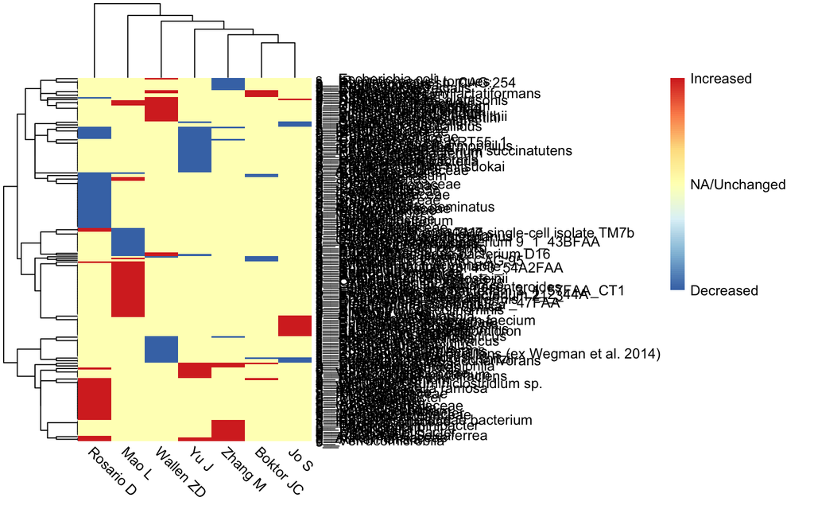

```r
tmp <- bsdb_PD_signatures_splitMethods$WMS %>%
  mutate(signatureSplit = paste(`MetaPhlAn taxon names`, collapse = ";")) %>%
  separate_rows(`MetaPhlAn taxon names`, sep = ";") %>%
  mutate(
    incr_decr = case_when(
      `Abundance in Group 1` == "increased" ~ 1,
      `Abundance in Group 1` == "decreased" ~  - 1,
      TRUE ~ 0
      ),
    FirstAuth = str_split(`Authors list`, pattern = ", ") %>% sapply("[[", 1)) %>%
  rename(taxaNames = `MetaPhlAn taxon names`) %>%
  select(taxaNames, FirstAuth, incr_decr) %>%
  distinct()

#' Manually remove Clostridiaceae family increase in Rosario D, which
#' causes a conflict AND is only found increased in PD, in the paper
tmp %<>%
  filter(!(FirstAuth == "Rosario D" & incr_decr == -1 & grepl("Clostridiaceae", taxaNames)))

tmp_wide <- pivot_wider(tmp, names_from = "FirstAuth", values_from = "incr_decr") %>%
  column_to_rownames("taxaNames")

rownames(tmp_wide) <- str_split(rownames(tmp_wide), "\\|") %>% sapply(function(x) x[length(x)])

tmp_wide[is.na(tmp_wide)] <- 0

tmp_wide %>%
pheatmap(legend_breaks = c(-1, 0, 1), legend_labels = c("Decreased", "NA/Unchanged", "Increased"), angle_col = 315)
```

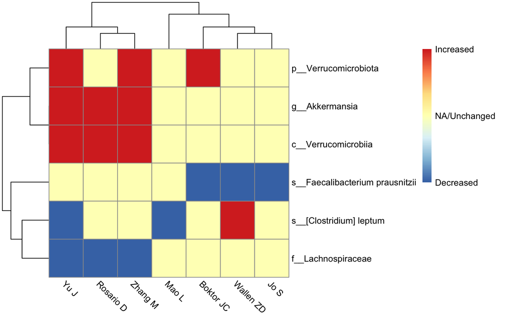

```r
tmp_wide[rowSums(abs(tmp_wide)) > 2,] %>%
pheatmap(legend_breaks = c(-1, 0, 1), legend_labels = c("Decreased", "NA/Unchanged", "Increased"), angle_col = 315)
```

As can be seen, most signatures are unique to the study. This is due to the typical sources of variability in studies, that include, among all:

1. Data generation steps

```
* sample collection

* DNA extraction

* Sequencing platform
```

2. Data processing steps

```
* Fastq filtering

* Fastq trimming

* profiling methods
```

3. Analysis choices

```
* Prevalence/abundance cutoff

* Data transformation/scaling/normalization

* Model assumptions

* Covariate adjustment
```

Our meta-analysis will aim to minimize the effect of steps 2 and 3. Adjusting for DNA extraction and sequencing method could help minimizing that bias too.

# 5 PubMed querying strategy

## 5.1 Not all shotgun publications in my list are in PubMed query results

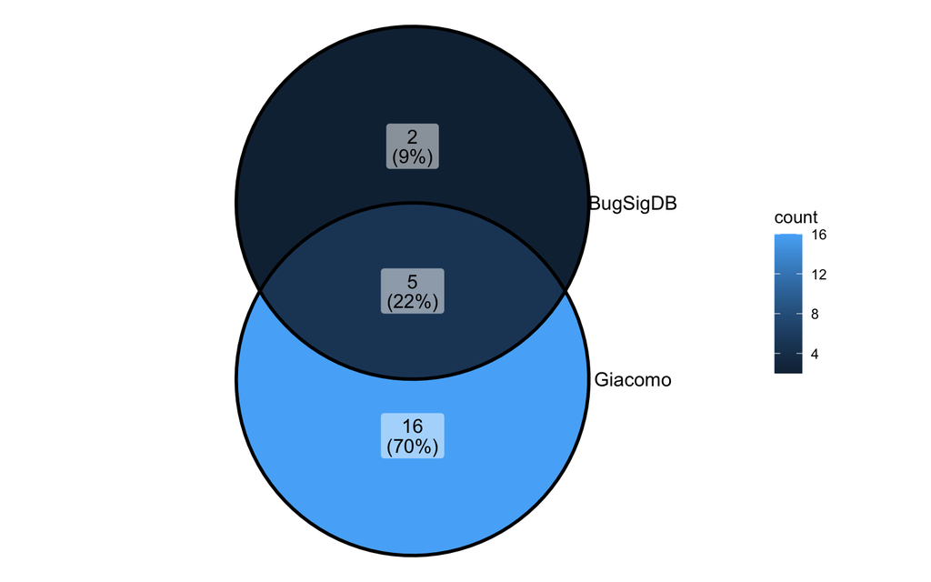

Figure 5.1: Venn diagram of shotgun studies included in BugSigDB and Giacomo’s lists. NB: Giacomo’s list included 4 preprints

```r
shotgun_curated_studies_BugSigDB <- studies_table_clean %>%
  filter(`Sequencing type` == "WMS")

shotgun_curated_studies_GA <- read_tsv("~/Documents/git_repos/parkinsons_data_search/parkinson_shotgun_datasets.tsv")


ggVennDiagram::ggVennDiagram(list("Giacomo" = shotgun_curated_studies_GA$`doi.org link`, "BugSigDB" = shotgun_curated_studies_BugSigDB$DOI)) +
  scale_x_continuous(expand = c(-1.5,1.5))
```

# 6 Comments on BugSigDB based on my query

- Some `Body site`s can be further curated, because there is a “Feces,Blood” study that could be put into the more numerous “Blood,Feces” category. (PMID: 35645785).
- PMID 33293403 curation should be reviewed, I think, for the following reasons:
  1. The `Condition` is idiopathic rapid eye movement sleep behavior disorder, not `Parkinson's disease`
  2. `Body site` says “Intestine” but should “Feces”

  The curator is “Aishat”, no reviewer
- The `createStudyTable` is a nice function but could be expanded, maybe to include more options, while leaving a default. **I”m working on a GitHub issue or feature request**

# 7 IBS signatures in BugSigDB

```r
condition_of_interest <- "Irritable Bowel Syndrome"
efo_id <- "EFO:0000555"
host <- "Homo sapiens"


cbind(c("Condition", "EFO ID", "Host species"), c(condition_of_interest, efo_id, host)) %>%
  set_colnames(c("Parameter", "Value")) %>%
  kbl() %>%
  kable_styling()
```

| Parameter | Value |
| --- | --- |
| Condition | Irritable Bowel Syndrome |
| EFO ID | EFO:0000555 |
| Host species | Homo sapiens |

```r
bsdb_IBS_signatures_allMethods <- filter(bsdb,
       # get studies/signatures on Parkinson alone
       grepl(efo_id, `EFO ID`),
       # restrict search to Homo sapiens
       `Host species` == host
       )
```

```r
createStudyTable2(bsdb_IBS_signatures_allMethods) %>%
  reactable(filterable = TRUE, searchable = TRUE)
```

| StudyCount | Study code | Condition | Body site | Experiment | Cases | Controls | Study design | PMID | DOI |
| --- | --- | --- | --- | --- | --- | --- | --- | --- | --- |
| 1 | BarandouziZA_2021 | Irritable bowel syndrome | Feces | Experiment 1 | 80 | 21 | cross-sectional observational, not case-control | 33429936 | https://doi.org/10.3390/jpm11010035 |
| 2 | CarrollIM_2011 | Irritable bowel syndrome | Feces,Colonic mucosa | Experiment 1 | 16 | 21 | case-control | 21737778 | https://doi.org/10.1152%2Fajpgi.00154.2011 |
| 3 | CarrollIM_2012 | Irritable bowel syndrome | Feces | Experiment 1 | 23 | 23 | case-control | 22339879 | https://doi.org/10.1111/j.1365-2982.2012.01891.x |
| 3 | CarrollIM_2012 | Irritable bowel syndrome | Feces | Experiment 2 | 23 | 23 | case-control | 22339879 | https://doi.org/10.1111/j.1365-2982.2012.01891.x |
| 4 | ChassardC_2012 | Irritable bowel syndrome | Feces | Experiment 1 | 14 | 12 | case-control | 22315951 | https://doi.org/10.1111/j.1365-2036.2012.05007.x |
| 5 | DubocH_2012 | Irritable bowel syndrome | Feces | Experiment 1 | 14 | 18 | case-control | 22356587 | https://doi.org/10.1111/j.1365-2982.2012.01893.x |
| 6 | FourieNH_2016 | Irritable bowel syndrome | Buccal mucosa | Experiment 1 | 9 | 20 | case-control | 26963804 | https://doi.org/10.1080/19490976.2016.1162363 |
| 6 | FourieNH_2016 | Irritable bowel syndrome | Buccal mucosa | Experiment 2 | 11 | 20 | case-control | 26963804 | https://doi.org/10.1080/19490976.2016.1162363 |
| 7 | JacobsJP_2023 | Irritable bowel syndrome | Feces | Experiment 1 | 318 | 177 | case-control | 36624530 | https://doi.org/10.1186/s40168-022-01450-5 |
| 8 | KerckhoffsAP_2009 | Irritable bowel syndrome | Feces,Mucosa of small intestine | Experiment 1 | 41 | 26 | case-control | 19533811 | https://doi.org/10.3748/wjg.15.2887 |

[output cut: 32 more lines]

```r
createTaxonTable(bsdb_IBS_signatures_allMethods) %>%
  filter(`Binomial Test pval` < 0.05) %>%
  reactable(filterable = TRUE, searchable = TRUE)
```

| Taxon Name | Taxonomic Level | total_signatures | increased_signatures | decreased_signatures | Binomial Test pval | kingdom | phylum | class | order | family | genus | species | n_signatures | metaphlan_name |
| --- | --- | --- | --- | --- | --- | --- | --- | --- | --- | --- | --- | --- | --- | --- |
| Prevotella | genus | 12 | 2 | 10 | 0.039 | Bacteria | Bacteroidota | Bacteroidia | Bacteroidales | Prevotellaceae | Prevotella | NA | 13 | k__Bacteria\|p__Bacteroidota\|c__Bacteroidia\|o__Bacteroidales\|f__Prevotellaceae\|g__Prevotella |
| Clostridioides difficile | species | 6 | 6 | 0 | 0.031 | Bacteria | Bacillota | Clostridia | Peptostreptococcales | Peptostreptococcaceae | Clostridioides | Clostridioides difficile | 6 | k__Bacteria\|p__Bacillota\|c__Clostridia\|o__Peptostreptococcales\|f__Peptostreptococcaceae\|g__Clostridioides\|s__Clostridioides difficile |

# 8 IBD signatures in BugSigDB

```r
condition_of_interest <- "Inflammatory Bowel Disease"
efo_id <- "EFO:0003767"
host <- "Homo sapiens"


cbind(c("Condition", "EFO ID", "Host species"), c(condition_of_interest, efo_id, host)) %>%
  set_colnames(c("Parameter", "Value")) %>%
  kbl() %>%
  kable_styling()
```

| Parameter | Value |
| --- | --- |
| Condition | Inflammatory Bowel Disease |
| EFO ID | EFO:0003767 |
| Host species | Homo sapiens |

```r
bsdb_IBD_signatures_allMethods <- filter(bsdb,
       # get studies/signatures on Parkinson alone
       grepl(efo_id, `EFO ID`),
       # restrict search to Homo sapiens
       `Host species` == host
       )
```

```r
createStudyTable2(bsdb_IBD_signatures_allMethods) %>%
  reactable(filterable = TRUE, searchable = TRUE)
```

| StudyCount | Study code | Condition | Body site | Experiment | Cases | Controls | Study design | PMID | DOI |
| --- | --- | --- | --- | --- | --- | --- | --- | --- | --- |
| 1 | KiernanMG_2019 | Inflammatory bowel disease | Mesenteric lymph node | Experiment 1 | 5 | 8 | cross-sectional observational, not case-control | 30239655 | https://doi.org/10.1093/ecco-jcc/jjy136 |
| 1 | KiernanMG_2019 | Inflammatory bowel disease | Mesenteric lymph node | Experiment 2 | 5 | 8 | cross-sectional observational, not case-control | 30239655 | https://doi.org/10.1093/ecco-jcc/jjy136 |
| 2 | NA_NA | Inflammatory bowel disease | Feces | Experiment 1 | 34 | 35 | prospective cohort | 33653942 | https://doi.org/10.1128/mSystems.00984-20 |
| 3 | OlbjørnC_2022 | Inflammatory bowel disease | Feces | Experiment 1 | 107 | 75 | case-control | 35888992 | https://doi.org/10.3390/microorganisms10071273 |
| 3 | OlbjørnC_2022 | Inflammatory bowel disease | Feces | Experiment 2 | 50 | 75 | case-control | 35888992 | https://doi.org/10.3390/microorganisms10071273 |
| 3 | OlbjørnC_2022 | Inflammatory bowel disease | Feces | Experiment 3 | 110 | 50 | case-control | 35888992 | https://doi.org/10.3390/microorganisms10071273 |
| 4 | PisaniA_2022 | Inflammatory bowel disease | Feces | Experiment 1 | 66 | 97 | cross-sectional observational, not case-control | 35532243 | https://doi.org/10.1128/spectrum.00616-22 |
| 4 | PisaniA_2022 | Inflammatory bowel disease | Feces | Experiment 2 | 32 | 97 | cross-sectional observational, not case-control | 35532243 | https://doi.org/10.1128/spectrum.00616-22 |
| 4 | PisaniA_2022 | Inflammatory bowel disease | Feces | Experiment 3 | 66 | 32 | cross-sectional observational, not case-control | 35532243 | https://doi.org/10.1128/spectrum.00616-22 |

```r
createTaxonTable(bsdb_IBD_signatures_allMethods) %>%
  filter(`Binomial Test pval` < 0.05) %>%
  reactable(filterable = TRUE, searchable = TRUE)
```

| Taxon Name | Taxonomic Level | total_signatures | increased_signatures | decreased_signatures | Binomial Test pval | kingdom | phylum | class | order | family | genus | species | n_signatures | metaphlan_name |
| --- | --- | --- | --- | --- | --- | --- | --- | --- | --- | --- | --- | --- | --- | --- |

# 9 Constipation signatures in BugSigDB

The following code is run but does not return studies nor signatures. That is because, to this date, BugSigDB has not been populated with studies that have looked directly at **constipation** as `Condition`.

Feel free to verify, but also a View(bsdb) followed by a general search of “constip” did not produce results except in co-occurrence with Autism spectrum disorder or with Parkinson disease

```r
condition_of_interest <- "Constipation"
efo_id <- "NCIT:C37930"
host <- "Homo sapiens"


cbind(c("Condition", "EFO ID", "Host species"), c(condition_of_interest, efo_id, host)) %>%
  set_colnames(c("Parameter", "Value")) %>%
  kbl() %>%
  kable_styling()
```

| Parameter | Value |
| --- | --- |
| Condition | Constipation |
| EFO ID | NCIT:C37930 |
| Host species | Homo sapiens |

```r
bsdb_constipation_signatures_allMethods <- filter(bsdb,
       # get studies/signatures on Parkinson alone
       grepl(efo_id, `EFO ID`),
       # restrict search to Homo sapiens
       `Host species` == host
       )
```

```r
createStudyTable2(bsdb_constipation_signatures_allMethods) %>%
  reactable(filterable = TRUE, searchable = TRUE)
```

```r
createTaxonTable(bsdb_constipation_signatures_allMethods) %>%
  filter(`Binomial Test pval` < 0.05) %>%
  reactable(filterable = TRUE, searchable = TRUE)
```